# Data Visualization: `ggplot` part 1

## Learning Goals

*At the end of this exercise, you will be able to:*  
1. Produce boxplots using `ggplot.`  
2. Customize labels on axes using `labs` and `themes`.  
3. Use `color`, `fill`, and `group` to customize plots and improve overall aesthetics.

## Breakout Rooms

Please take 5-8 minutes to check over your answers to HW 8 in your group. If you are stuck, please remember that you can check the key in [Joel’s repository](https://github.com/jmledford3115/BIS15LW2022_jledford).

##Resources - [ggplot2 cheatsheet](https://www.rstudio.com/wp-content/uploads/2015/03/ggplot2-cheatsheet.pdf) - [`ggplot` themes](https://ggplot2.tidyverse.org/reference/ggtheme.html) - [Rebecca Barter `ggplot` Tutorial](http://www.rebeccabarter.com/blog/2017-11-17-ggplot2_tutorial/)

## Load the libraries

```r
library(tidyverse)
library(skimr)
library(janitor)
library(here)
library(palmerpenguins)
```

## Review

Now that you have been introduced to `ggplot`, let’s practice a few more plot types. Remember that plots are built in layers: **plot= data + geom_ + aesthetics**. We have to specify each of these in order for a plot to be produced. If you get stuck, it is often helpful to stop and make a quick sketch of what you want or expect to see on a piece of scratch paper.

Let’s review using the `penguins` data. First, get an idea of the structure: Are the data tidy? Are there NA’s? Are the variables discrete, categorical, or continuous?

```r
penguins
```

```
## # A tibble: 344 x 8
##    species island    bill_length_mm bill_depth_mm flipper_length_mm body_mass_g
##    <fct>   <fct>              <dbl>         <dbl>             <int>       <int>
##  1 Adelie  Torgersen           39.1          18.7               181        3750
##  2 Adelie  Torgersen           39.5          17.4               186        3800
##  3 Adelie  Torgersen           40.3          18                 195        3250
##  4 Adelie  Torgersen           NA            NA                  NA          NA
##  5 Adelie  Torgersen           36.7          19.3               193        3450
##  6 Adelie  Torgersen           39.3          20.6               190        3650
##  7 Adelie  Torgersen           38.9          17.8               181        3625
##  8 Adelie  Torgersen           39.2          19.6               195        4675
##  9 Adelie  Torgersen           34.1          18.1               193        3475
## 10 Adelie  Torgersen           42            20.2               190        4250
## # ... with 334 more rows, and 2 more variables: sex <fct>, year <int>
```

In a previous lab, we asked how many penguins are on each island.

```r
penguins %>% count(island, species, sort = F)
```

```
## # A tibble: 5 x 3
##   island    species       n
##   <fct>     <fct>     <int>
## 1 Biscoe    Adelie       44
## 2 Biscoe    Gentoo      124
## 3 Dream     Adelie       56
## 4 Dream     Chinstrap    68
## 5 Torgersen Adelie       52
```

What if we wanted a plot that showed the number of measured penguins per species and the number of measured penguins per island?

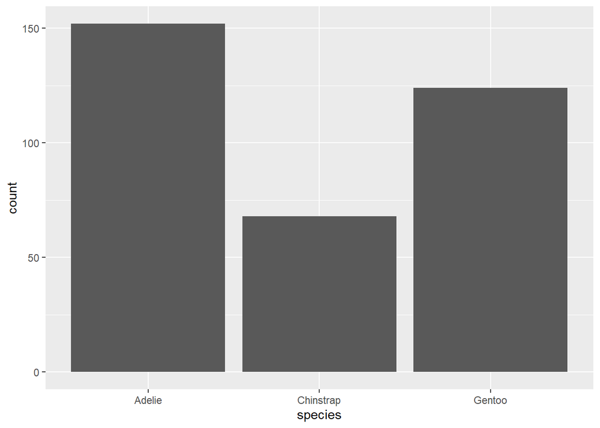

```r
penguins %>%
  group_by(island) %>%
  ggplot(aes(x=species))+
  geom_bar()
```

How about average bill length by sex?

```r
penguins %>%
  filter(sex!="NA") %>%
  group_by(sex) %>%
  summarise(ave_bill_length=mean(bill_length_mm))
```

```
## # A tibble: 2 x 2
##   sex    ave_bill_length
##   <fct>            <dbl>
## 1 female            42.1
## 2 male              45.9
```

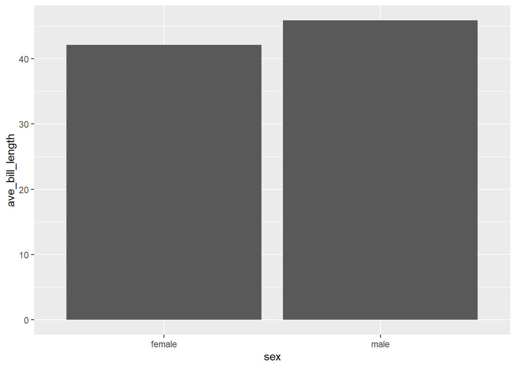

```r
penguins %>%
  filter(sex!="NA") %>%
  group_by(sex) %>%
  summarise(ave_bill_length=mean(bill_length_mm)) %>%
  ggplot(aes(x=sex, y=ave_bill_length)) +
  geom_col()
```

## Box Plots

For the next series of examples, we will use the `homerange` data. **Database of vertebrate home range sizes.**

Reference: Tamburello N, Cote IM, Dulvy NK (2015) Energy and the scaling of animal space use. The American Naturalist 186(2):196-211. http://dx.doi.org/10.1086/682070.  
Data: http://datadryad.org/resource/doi:10.5061/dryad.q5j65/1

```r
homerange <- read_csv(here("lab9", "data", "Tamburelloetal_HomeRangeDatabase.csv"))
homerange
```

```
## # A tibble: 569 x 24
##    taxon  common.name   class   order   family genus species primarymethod N
##    <chr>  <chr>         <chr>   <chr>   <chr>  <chr> <chr>   <chr>         <chr>
##  1 lake ~ american eel  actino~ anguil~ angui~ angu~ rostra~ telemetry     16
##  2 river~ blacktail re~ actino~ cyprin~ catos~ moxo~ poecil~ mark-recaptu~ <NA>
##  3 river~ central ston~ actino~ cyprin~ cypri~ camp~ anomal~ mark-recaptu~ 20
##  4 river~ rosyside dace actino~ cyprin~ cypri~ clin~ fundul~ mark-recaptu~ 26
##  5 river~ longnose dace actino~ cyprin~ cypri~ rhin~ catara~ mark-recaptu~ 17
##  6 river~ muskellunge   actino~ esocif~ esoci~ esox  masqui~ telemetry     5
##  7 marin~ pollack       actino~ gadifo~ gadid~ poll~ pollac~ telemetry     2
##  8 marin~ saithe        actino~ gadifo~ gadid~ poll~ virens  telemetry     2
##  9 marin~ lined surgeo~ actino~ percif~ acant~ acan~ lineat~ direct obser~ <NA>
## 10 marin~ orangespine ~ actino~ percif~ acant~ naso  litura~ telemetry     8
## # ... with 559 more rows, and 15 more variables: mean.mass.g <dbl>,
## #   log10.mass <dbl>, alternative.mass.reference <chr>, mean.hra.m2 <dbl>,
## #   log10.hra <dbl>, hra.reference <chr>, realm <chr>, thermoregulation <chr>,
## #   locomotion <chr>, trophic.guild <chr>, dimension <dbl>, preymass <dbl>,
## #   log10.preymass <dbl>, PPMR <dbl>, prey.size.reference <chr>
```

Boxplots help us visualize a range of values. So, on the x-axis we typically have something categorical and the y-axis is the range. In the case below, we are plotting `log10.mass` by taxonomic class in the `homerange` data. `geom_boxplot()` is the geom type for a standard box plot. The center line in each box represents the median, not the mean.

Let’s look at the variable `log10.mass` grouped by taxonomic class.

```r
homerange %>%
  group_by(class) %>%
  summarize(min_log10.mass=min(log10.mass),
            max_log10.mass=max(log10.mass),
            median_log10.mass=median(log10.mass))
```

```
## # A tibble: 4 x 4
##   class          min_log10.mass max_log10.mass median_log10.mass
##   <chr>                   <dbl>          <dbl>             <dbl>
## 1 actinopterygii         -0.658           3.55              2.08
## 2 aves                    0.712           4.95              1.82
## 3 mammalia                0.620           6.60              3.33
## 4 reptilia                0.539           4.03              2.51
```

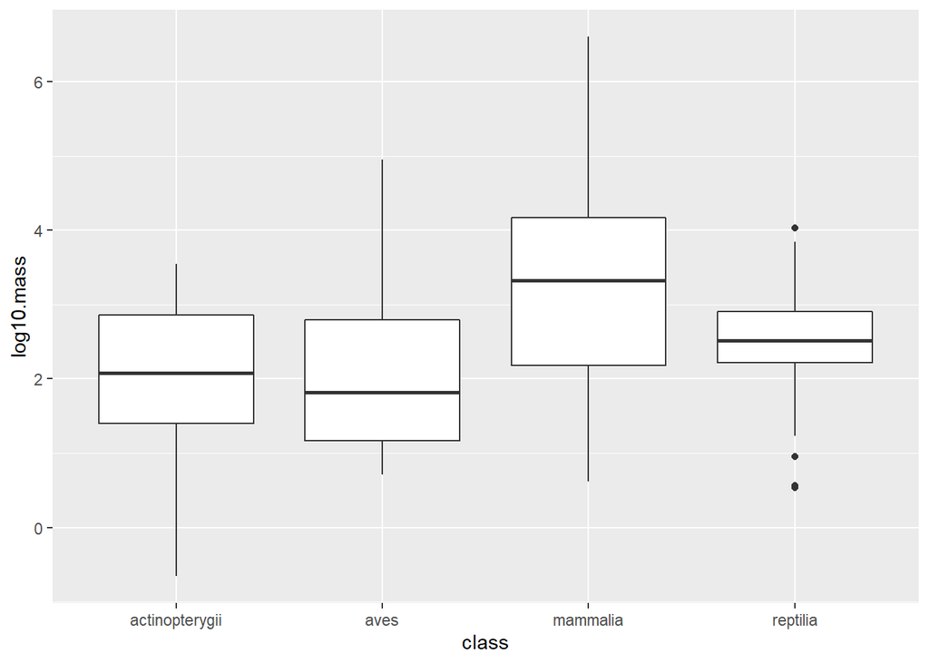

```r
homerange %>%
  ggplot(aes(x = class, y = log10.mass)) +
  geom_boxplot()
```

## Practice

1. There are more herbivores than carnivores in the homerange data, but how do their masses compare? Make a summary and boxplot that compares their masses. Use `log10.mass`.

```r
homerange_masses<-
  homerange%>%
  group_by(trophic.guild, log10.mass)%>%
  summarise( mean_log10= mean(log10.mass), min_log10= min(log10.mass), max_log10=max(log10.mass))
homerange_masses
```

```
## # A tibble: 535 x 5
## # Groups:   trophic.guild [2]
##    trophic.guild log10.mass mean_log10 min_log10 max_log10
##    <chr>              <dbl>      <dbl>     <dbl>     <dbl>
##  1 carnivore        -0.658     -0.658    -0.658    -0.658
##  2 carnivore        -0.509     -0.509    -0.509    -0.509
##  3 carnivore        -0.347     -0.347    -0.347    -0.347
##  4 carnivore         0.0864     0.0864    0.0864    0.0864
##  5 carnivore         0.301      0.301     0.301     0.301
##  6 carnivore         0.431      0.431     0.431     0.431
##  7 carnivore         0.477      0.477     0.477     0.477
##  8 carnivore         0.494      0.494     0.494     0.494
##  9 carnivore         0.539      0.539     0.539     0.539
## 10 carnivore         0.543      0.543     0.543     0.543
## # ... with 525 more rows
```

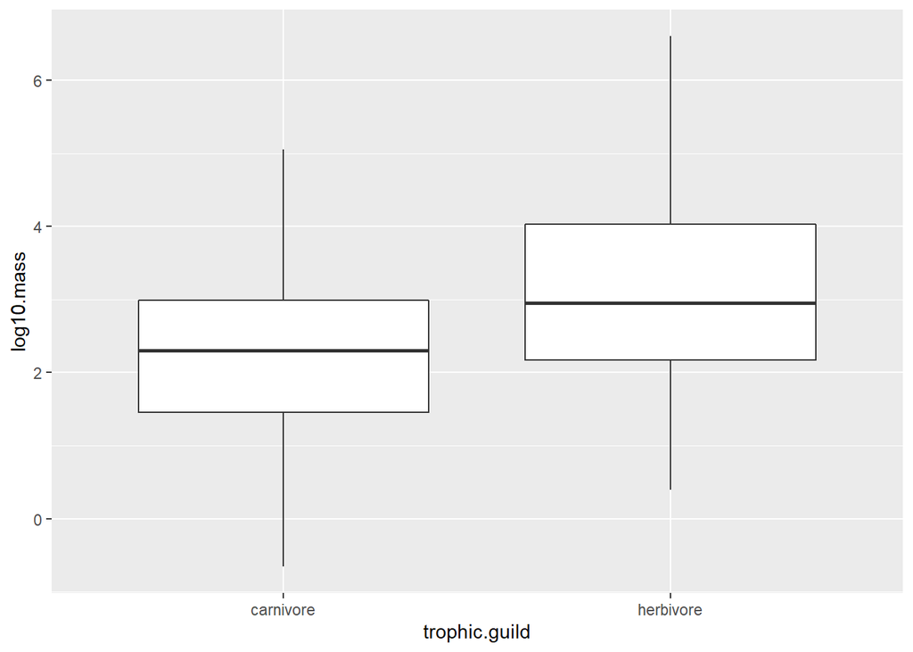

```r
homerange_masses%>%
  ggplot(aes(x=trophic.guild, y= log10.mass))+
  geom_boxplot()
```

2. Have a closer look at carnivorous mammals. Summarize and visualize the range of log10.mass by family. coordflip

```r
  homerange%>%
  filter(class=="mammalia", trophic.guild== "carnivore")%>%
  select( family, trophic.guild, log10.mass)%>%
  summarise(mean_mass= mean(log10.mass))
```

```
## # A tibble: 1 x 1
##   mean_mass
##       <dbl>
## 1      3.03
```

```r
homerange %>%
  filter(class=="mammalia" & trophic.guild=="carnivore") %>%
  group_by(family) %>%
  summarize(mean_mass=mean(log10.mass))
```

```
## # A tibble: 18 x 2
##    family          mean_mass
##    <chr>               <dbl>
##  1 canidae             3.73
##  2 chrysochloridae     2.00
##  3 cricetidae          1.39
##  4 dasyuridae          2.32
##  5 didelphidae         1.38
##  6 erinaceidae         2.69
##  7 eupleridae          3.98
##  8 felidae             4.16
##  9 herpestidae         3.16
## 10 hyanidae            4
## 11 macroscelididae     2.27
## 12 mustelidae          3.08
## 13 peramelidae         2.74
## 14 soricidae           0.882
## 15 tachyglossidae      2.41
## 16 talpidae            1.90
## 17 ursidae             4.99
## 18 viverridae          3.49
```

3. Now use a boxplot to visualize the range of body mass by family of mammalian carnivore.

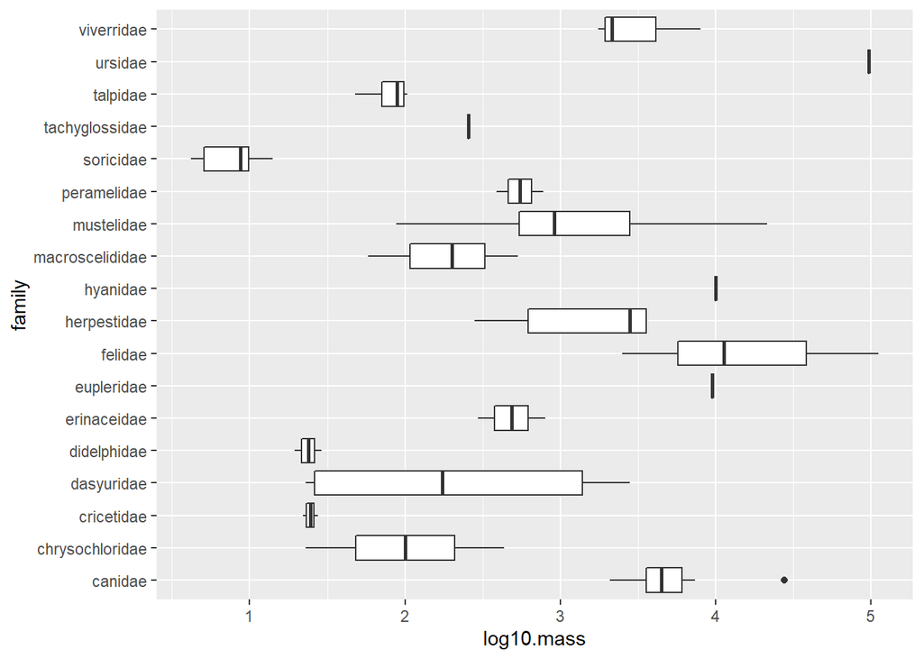

```r
homerange %>%
  filter(class=="mammalia" & trophic.guild=="carnivore") %>%
  select(family, trophic.guild, log10.mass) %>%
  ggplot(aes(x=family, y=log10.mass))+
  geom_boxplot()+
  coord_flip()
```

```r
glimpse(homerange)
```

```
## Rows: 569
## Columns: 24
## $ taxon                      <chr> "lake fishes", "river fishes", "river fishe~
## $ common.name                <chr> "american eel", "blacktail redhorse", "cent~
## $ class                      <chr> "actinopterygii", "actinopterygii", "actino~
## $ order                      <chr> "anguilliformes", "cypriniformes", "cyprini~
## $ family                     <chr> "anguillidae", "catostomidae", "cyprinidae"~
## $ genus                      <chr> "anguilla", "moxostoma", "campostoma", "cli~
## $ species                    <chr> "rostrata", "poecilura", "anomalum", "fundu~
## $ primarymethod              <chr> "telemetry", "mark-recapture", "mark-recapt~
## $ N                          <chr> "16", NA, "20", "26", "17", "5", "2", "2", ~
## $ mean.mass.g                <dbl> 887.00, 562.00, 34.00, 4.00, 4.00, 3525.00,~
## $ log10.mass                 <dbl> 2.9479236, 2.7497363, 1.5314789, 0.6020600,~
## $ alternative.mass.reference <chr> NA, NA, NA, NA, NA, NA, NA, NA, NA, NA, NA,~
## $ mean.hra.m2                <dbl> 282750.00, 282.10, 116.11, 125.50, 87.10, 3~
## $ log10.hra                  <dbl> 5.4514026, 2.4504031, 2.0648696, 2.0986437,~
## $ hra.reference              <chr> "Minns, C. K. 1995. Allometry of home range~
## $ realm                      <chr> "aquatic", "aquatic", "aquatic", "aquatic",~
## $ thermoregulation           <chr> "ectotherm", "ectotherm", "ectotherm", "ect~
## $ locomotion                 <chr> "swimming", "swimming", "swimming", "swimmi~
## $ trophic.guild              <chr> "carnivore", "carnivore", "carnivore", "car~
## $ dimension                  <dbl> 3, 2, 2, 2, 2, 2, 2, 2, 2, 2, 2, 2, 2, 3, 3~
## $ preymass                   <dbl> NA, NA, NA, NA, NA, NA, 1.39, NA, NA, NA, N~
## $ log10.preymass             <dbl> NA, NA, NA, NA, NA, NA, 0.1430148, NA, NA, ~
## $ PPMR                       <dbl> NA, NA, NA, NA, NA, NA, 530, NA, NA, NA, NA~
## $ prey.size.reference        <chr> NA, NA, NA, NA, NA, NA, "Brose U, et al. 20~
```

## That’s it, let’s take a break!

–>[Home](https://jmledford3115.github.io/datascibiol/)